# Regional Housing Framework

Post Clean Montgomery BK data and join it with county data

Patrick Spauster

February 13, 2019

Library: RegHsg

Project: Regional Housing Framework

Author: Patrick Spauster

Version: R 3.5.1, RStudio 1.1.423

Last updated June 19, 2019

Environment: Local Windows session (desktop)

## Set-up

Load libraries and functions

```r
library(tidyverse)
library(DescTools)
library(purrr)
library(sf)

source("../Macros/read-bk.R")
source("../Macros/filter-bk.R")
source("../Macros/select-vars.R")
source("../Macros/sample-properties.R")
source("../Macros/classify-addresses.R")
source("../Macros/max_narm.R")
source("../Macros/mode_narm.R")
```

Set FIPS code and filepath name

```r
currentfips <- "24031"
filepath <- "montgomery"
jdir <- paste0("L:/Libraries/RegHsg/Data/", filepath, "/")
rdir <- paste0("L:/Libraries/RegHsg/Raw/", filepath, "/")
```

Load in cleaned Black Knight data.

```r
jur <- readRDS(paste0(jdir,
               "cleaned-",
               filepath,
               "-data.Rdata"))
```

## Supplement with county data

Use county data sources to fill in missing information.

Read in zoning file (zoning_sf) to match to the collapsed BK data. Read in property file and master address file.

```r
zoning_sf <- read_sf(dsn = 'L:/Libraries/RegHsg/Raw/montgomery/montgomery-parcel-file/MCzoning_parcels',
                     layer = "MC_zoning")

# property shape stored in geodatabase- assign gdb for extraction
prop <- "L:/Libraries/RegHsg/Maps/montgomery/property/property.gdb"

# function below lists layers in geodatabase
# rgdal::ogrListLayers(prop)

propsf <- read_sf(prop, layer = "Property_poly_with_data")

# read in master address file
ma <- read_csv("L:/Libraries/RegHsg/Data/masteraddress_gis.csv",
               col_types = cols(
  ADDRID = col_double(),
  ADDR_STATUS = col_double(),
  ADDR_TYPE = col_double(),
  ADDR_DATE = col_character(),
  ADDR_NUMBER = col_double(),
  ADDR_NUMBER_SUFFIX = col_character(),
  PRE_DIR = col_character(),
  ST_NAME = col_character(),
  ST_TYPE = col_character(),
  SUF_DIR = col_character(),
  UNIT = col_character(),
  XCOORD = col_double(),
  YCOORD = col_double(),
  FULL_ADDRESS = col_character(),
  CITY = col_character(),
  ZIPCODE = col_double(),
  COMMENTS = col_character(),
  COUNTY_CODE = col_double(),
  DISTRICT = col_character(),
  ACCT = col_character(),
  SUBDIVISION = col_character(),
  SUBDIV_ID = col_double(),
  SUBDIV_NAME = col_character(),
  LOT = col_character(),
  BLOCK = col_character(),
  PARCEL_NO = col_character(),
  LU_CATEGORY = col_character(),
  CBPTEAM = col_double(),
  LONGZONE = col_character(),
  MASTERPLAN_CODE = col_character(),
  MASTERPLAN = col_character(),
  POLICY_NUMBER = col_double(),
  POLICY_AREA = col_character(),
  PRELIM_APNO = col_character(),
  SITE_APNO = col_character(),
  SAR_STATUS = col_character(),
  CHAMPTREE = col_character(),
  SFP_ES = col_character(),
  SFP_MS = col_character(),
  SFP_HS = col_character(),
  TPAR_REQ = col_character(),
  PAMR_REQ = col_character(),
  CONDITION_APNOS = col_character(),
  CHANGE_DATE = col_character(),
  X45 = col_character()
))
```

Use the property file to supplement lot size for parcels with no “C” in their ACCT. For those who do not match on this- supplement parcels with a “C” with the address file, which crosswalks addresses to parcels with “C”s. Then re-merge to the property file, and divide the area of the “C” parcels by the number of observations per parcel ID.

```r
# get rid of geomerty for processing time
prop_testing <- propsf %>%
  as.data.frame()

# select and create variables from property file to merge with black knight data
# select only obs with unique parcel ID
propmerge <- prop_testing %>%
  select(DISTRICT, ACCT,
         LU_CATEGORY,
         CONDO_UNIT_NO,
         NO_DWELLINGS, DWELLING_TYPE,
         PLANNING, POLICY, MASTER_PLAN,
         RES_DWELLU, LAND_ASSMT, IMPROV_ASSMT, Shape_Area) %>%
  mutate(parcel_id = paste0(DISTRICT, "-", ACCT),
         cflag = str_detect(ACCT, "C"),
         propflag = 1) %>%
  group_by(parcel_id) %>%
  filter(n() == 1) %>%
  ungroup()

# join black knight with property file
jur1 <- jur %>%
  mutate(missing_houseno = ifelse(is.na(prophouseno) &
                                    address_type == "single",
                                  1,
                                  0)) %>%
  left_join(propmerge, by = c("assessorsparcelnumberapnpin" = "parcel_id"))

# from master address file- select obs that are distinct address + parcel ID pairs
mac <- ma %>%
  filter(str_detect(ACCT, "C")) %>%
  group_by(FULL_ADDRESS) %>%
  summarize(acct_list = list(ACCT)) %>%
  mutate(num = map_dbl(acct_list, ~ length(unique(.))),
         house1 = substr(FULL_ADDRESS, 1, 2)) %>%
  filter(num == 1,
         # get rid of observations with house numbers of 0
         !house1 == "0 ") %>%
  mutate(ACCT_address = map_chr(acct_list, 1))

# use this as parcel-address crosswalk
macmerge <- mac %>%
  select(FULL_ADDRESS, ACCT_address)

# join only obs that did not match in parcel file and do not have missing addresses
jur1a <- jur1 %>%
  filter(is.na(propflag),
         missing_houseno == 0) %>%
  select(-c(38:48)) %>%
  left_join(macmerge, by = c("propaddress" = "FULL_ADDRESS"))

# see how many obs in the black knight data did not have a match in the master address file
jur1 %>%
  filter(is.na(propflag),
         missing_houseno == 0) %>%
  anti_join(mac, by = c("propaddress" = "FULL_ADDRESS")) %>%
  nrow()
```

```
## [1] 5201
```

```r
# join by parcel ID back to property file
jur1b <- jur1a %>%
  left_join(propmerge, by = c("ACCT_address" = "ACCT")) %>%
  group_by(ACCT_address) %>%
  # divide area by the number of parcels
  mutate(lot_acct = Shape_Area.y / n(),
         clotflag = 1) %>%
  ungroup()

# test how many and which type of properties did not join
jur1banti <- jur1a %>%
  anti_join(propmerge, by = c("ACCT_address" = "ACCT")) %>%
  count(category_detail)
```

## Fill lot size.

Recombine and replace lot size with the appropriate measure.

```r
# recombine with obs that joined to property file or have missing house number
jur2 <- jur1 %>%
  filter(propflag == 1 & !is.na(propflag) |
         missing_houseno == 1) %>%
  bind_rows(jur1b) %>%
  # create a flag for when the subsetted area should be used
  mutate(clotflag = ifelse(is.na(clotflag),
                           0,
                           clotflag))


jur3 <- jur2 %>%
  mutate(arc_lotsize = lotsize_sf,
         lotsize_sf = case_when(
    # if subsetted area is available, use this
    clotflag == 1 ~ lot_acct,
    # if area was not subsetted and original lot size is missing, use the shape area
    clotflag == 0 & is.na(arc_lotsize) ~ Shape_Area,
    # if neither of these things are true, keep black knight lot size
    TRUE ~ lotsize_sf
  ))

# test how many properties have missing lot size
jur3 %>%
  group_by(category_detail) %>%
  summarize(n(),
            sum(is.na(lotsize_sf)),
            sum(lotsize_sf == 0, na.rm = TRUE)) %>%
  knitr::kable()
```

| category_detail | n() | sum(is.na(lotsize_sf)) | sum(lotsize_sf == 0, na.rm = TRUE) |
| --- | --- | --- | --- |
| apartment | 961 | 53 | 0 |
| condo | 17656 | 992 | 0 |
| mf other | 21 | 2 | 0 |
| mixeduse | 52 | 1 | 0 |
| NULL | 2 | 0 | 0 |
| other | 17757 | 1553 | 0 |
| sf detached | 180109 | 378 | 0 |
| townhouse | 56318 | 5 | 0 |
| vacant mf | 88 | 45 | 0 |
| vacant mixed use | 8 | 1 | 0 |
| vacant residential | 16625 | 2402 | 0 |

Look at the difference between shape area and the original black knight lot size- make sure it is not severly skewed one way.

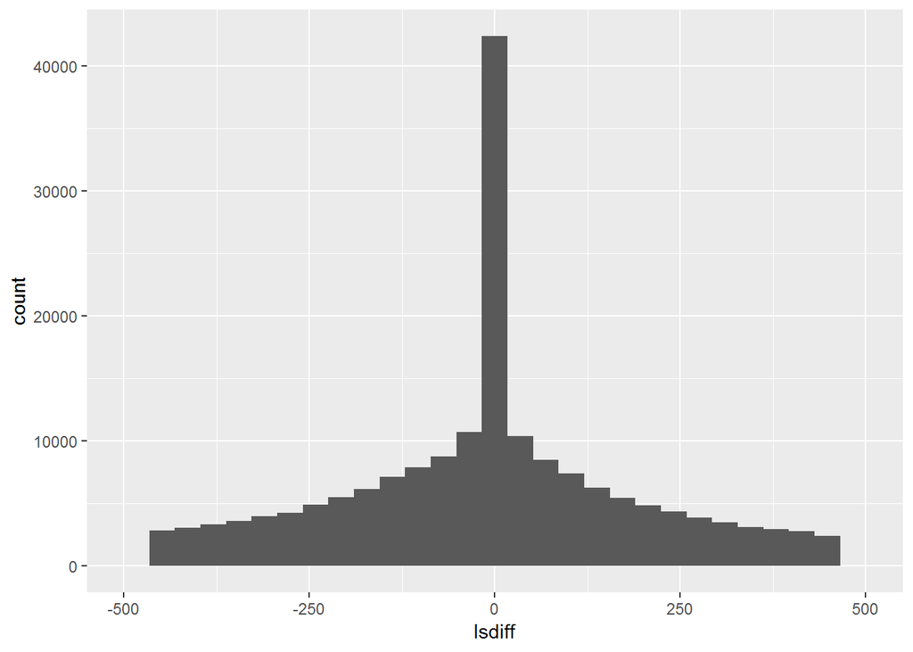

```r
jur3 %>%
  mutate(lsdiff = Shape_Area - arc_lotsize) %>%
  filter(!is.na(arc_lotsize),
         !is.na(Shape_Area),
         clotflag != 1) %>%
  ggplot() +
  geom_histogram(mapping = aes(lsdiff)) +
  scale_x_continuous(limits = c(-500, 500))
```

### Fix land use

Use the property land use file to fix Black Knight land use where it is (most likely) wrong.

```r
landuse <- pull(prop_testing, LU_CATEGORY) %>% unique() %>% sort()

landuse_recode <- tibble(LU_CATEGORY = landuse,
                         landuse_residential =
                           c(0, 1, 0, NA, 0, 0,
                             1, 0, 0, 0, 0, 0,
                             0, 1, 1, 0, 0, 0),
                         landuse_category = c("other", "mf", "other",
                                              NA, "other", "other",
                                              "mf", "other", "other",
                                              "other", "other", "other",
                                              "other", "sf", "sf",
                                              "other", "vacant", "other"))

jur3a <- jur3 %>%
  left_join(landuse_recode, by = "LU_CATEGORY")

jur3a %>%
  count(residential == landuse_residential)
```

```
## # A tibble: 3 x 2
##   `residential == landuse_residential`      n
##   <lgl>                                 <int>
## 1 FALSE                                 17587
## 2 TRUE                                 266358
## 3 NA                                     5652
```

```r
jur3a %>%
  count(category == landuse_category)
```

```
## # A tibble: 3 x 2
##   `category == landuse_category`      n
##   <lgl>                           <int>
## 1 FALSE                           19917
## 2 TRUE                           264028
## 3 NA                               5652
```

```r
jur3a <- jur3a %>%
  mutate(residential = ifelse(!is.na(landuse_residential) &
                                residential != landuse_residential,
                              landuse_residential,
                              residential),
         category = ifelse(!is.na(landuse_category) &
                           category != landuse_category,
                           landuse_category,
                           category))

jur3a %>%
  count(residential == landuse_residential)
```

```
## # A tibble: 2 x 2
##   `residential == landuse_residential`      n
##   <lgl>                                 <int>
## 1 TRUE                                 283945
## 2 NA                                     5652
```

```r
jur3a %>%
  count(category == landuse_category)
```

```
## # A tibble: 2 x 2
##   `category == landuse_category`      n
##   <lgl>                           <int>
## 1 TRUE                           283945
## 2 NA                               5652
```

```r
jur3a %>%
  count(category)
```

```
## # A tibble: 4 x 2
##   category      n
##   <chr>     <int>
## 1 mf         6940
## 2 other     17153
## 3 sf       251360
## 4 vacant    14144
```

## Spatial joins

Next, use a spatial join to make flags for Rockville and Gaithersburg.

Convert Black Knight data to spatial.

```r
jur4 <- jur3a %>%
  mutate(missing_coord = ifelse(is.na(lat) | is.na(long),
                                1,
                                0))

jur4 <- jur4 %>% #archive the lat and long so that we can do multiples spatial joins. SF replace lat long with an SF object
  mutate(latarc = lat) %>%
  mutate(longarc = long) %>%
  mutate(lat1 = lat) %>%
  mutate(long1 = long) %>%
  mutate(lat2 = lat) %>%
  mutate(long2 = long)


jur_sf <- jur4 %>% #set geometry
  filter(missing_coord == 0) %>%
  st_as_sf(coords = c("long", "lat")) %>%
  st_set_crs(st_crs(4326))
```

### Zoning code: fill zoning

Find the invalid geometries in the zoning code

```r
zoning_sf1 <- zoning_sf %>%
  # there is one large shape overlayed over all the other shapes- filter this out
  filter(PERIMETER == 0) %>%
  mutate(validgeo = ifelse(st_is_valid(st_sfc(geometry)),
                                1,
                                0))

zoning_sf1 %>% as.data.frame() %>%
  count(validgeo)
```

```
## # A tibble: 2 x 2
##   validgeo     n
##      <dbl> <int>
## 1        0    12
## 2        1  8278
```

```r
# transform CRS to be consistent with Black Knight data
zoning_sf1 <- st_transform(zoning_sf1, crs = 4326)
```

Join the Black Knight data to the zoning code to fill in missing instances.

```r
zjoin <- st_join(jur_sf, zoning_sf1, join = st_intersects)

# Make sure test variable is never missing
zoning_sf1 %>% as.data.frame() %>%
  count(is.na(ZONE_))
```

```
## # A tibble: 1 x 2
##   `is.na(ZONE_)`     n
##   <lgl>          <int>
## 1 FALSE           8290
```

```r
zjoin %>%
  as.data.frame() %>%
  count(is.na(ZONE_))
```

```
## # A tibble: 2 x 2
##   `is.na(ZONE_)`      n
##   <lgl>           <int>
## 1 FALSE          244446
## 2 TRUE            35219
```

```r
zjoin <- zjoin %>%
  mutate(notinmont = if_else(is.na(ZONE_), 1, 0))

zjoin %>%
  as.data.frame() %>%
  count(notinmont)
```

```
## # A tibble: 2 x 2
##   notinmont      n
##       <dbl>  <int>
## 1         0 244446
## 2         1  35219
```

### Jurisdiction flags

Our Data on the property city is not reliable, so we need to create a flag ourselves using the Tiger line shapefiles.

```r
#read in tiger line place file to create flags for places with their own zoning codes

placepfile <- str_sub(list.files('L:/Libraries/RegHsg/Raw/montgomery/placefile'),
                     end = -5) %>% unique()
Mocoplaces_sf <- read_sf(dsn = 'L:/Libraries/RegHsg/Raw/montgomery/placefile',
                     layer = placepfile[1])

Mocoplaces_sf1 <- Mocoplaces_sf %>%
  mutate(validgeo = ifelse(st_is_valid(st_sfc(geometry)),
                                1,
                                0))
Mocoplaces_sf1 %>% as.data.frame() %>%
  count(validgeo)
```

```
## # A tibble: 1 x 2
##   validgeo     n
##      <dbl> <int>
## 1        1   518
```

```r
st_geometry(Mocoplaces_sf1)
```

```
## Geometry set for 518 features
## geometry type:  MULTIPOLYGON
## dimension:      XY
## bbox:           xmin: -79.48356 ymin: 37.952 xmax: -75.04912 ymax: 39.72302
## epsg (SRID):    4269
## proj4string:    +proj=longlat +datum=NAD83 +no_defs
## First 5 geometries:
```

```r
Mocoplaces_sf2 <- st_transform(Mocoplaces_sf1, crs = 4326)


pjoin <- st_join(zjoin, Mocoplaces_sf2, join = st_intersects)

pjoin2 <- pjoin %>%
  # make Rockville flag
  mutate(rockflag = if_else(NAME=="Rockville",1,0),
         rockflag = if_else(is.na(NAME),0,rockflag),
         gaitflag = if_else(NAME=="Gaithersburg",1,0),
         gaitflag = if_else(is.na(NAME),0,gaitflag),
         othernotmoco = if_else(NAME %in% c("Barnesville","Brookville","Laytonsville","Poolesville"),1,0),
         othernotmoco = if_else(is.na(NAME),0,othernotmoco)

  )
count(pjoin2,rockflag)
```

```
## Simple feature collection with 2 features and 2 fields
## geometry type:  MULTIPOINT
## dimension:      XY
## bbox:           xmin: -77.51923 ymin: 38.93898 xmax: -76.90444 ymax: 39.35149
## epsg (SRID):    4326
## proj4string:    +proj=longlat +datum=WGS84 +no_defs
## # A tibble: 2 x 3
##   rockflag      n                                                  geometry
##      <dbl>  <int>                                         <MULTIPOINT [Â°]>
## 1        0 263411 (-77.51923 39.15461, -77.51258 39.1458, -77.51153 39.155~
## 2        1  16254 (-77.1996 39.08032, -77.19907 39.0798, -77.19838 39.0844~
```

```r
count(pjoin2,gaitflag)
```

```
## Simple feature collection with 2 features and 2 fields
## geometry type:  MULTIPOINT
## dimension:      XY
## bbox:           xmin: -77.51923 ymin: 38.93898 xmax: -76.90444 ymax: 39.35149
## epsg (SRID):    4326
## proj4string:    +proj=longlat +datum=WGS84 +no_defs
## # A tibble: 2 x 3
##   gaitflag      n                                                  geometry
##      <dbl>  <int>                                         <MULTIPOINT [Â°]>
## 1        0 264734 (-77.51923 39.15461, -77.51258 39.1458, -77.51153 39.155~
## 2        1  14931 (-77.25783 39.12056, -77.25552 39.11863, -77.25501 39.11~
```

```r
count(pjoin2,othernotmoco)
```

```
## Simple feature collection with 2 features and 2 fields
## geometry type:  MULTIPOINT
## dimension:      XY
## bbox:           xmin: -77.51923 ymin: 38.93898 xmax: -76.90444 ymax: 39.35149
## epsg (SRID):    4326
## proj4string:    +proj=longlat +datum=WGS84 +no_defs
## # A tibble: 2 x 3
##   othernotmoco      n                                              geometry
##          <dbl>  <int>                                     <MULTIPOINT [Â°]>
## 1            0 277323 (-77.51923 39.15461, -77.51258 39.1458, -77.51153 39~
## 2            1   2342 (-77.43414 39.14875, -77.43243 39.15842, -77.43102 3~
```

#### Rockville

Read in Rockville shapefile.

```r
rockpfile <- str_sub(list.files('L:/Libraries/RegHsg/Raw/montgomery/Rockville_zoning_districts'),
                     end = -5) %>% unique()

rockzoning_sf <- read_sf(dsn = 'L:/Libraries/RegHsg/Raw/montgomery/Rockville_zoning_districts',
                     layer = rockpfile[1])

rockzoning_sf1 <- rockzoning_sf %>%
  mutate(validgeo = ifelse(st_is_valid(st_sfc(geometry)),
                                1,
                                0))
rockzoning_sf1 %>% as.data.frame() %>%
  count(validgeo)
```

```
## # A tibble: 1 x 2
##   validgeo     n
##      <dbl> <int>
## 1        1    21
```

```r
rockzoning_sf1 <- rockzoning_sf1 %>%
  filter(validgeo == 1 & !is.na(validgeo))

st_geometry(rockzoning_sf1)
```

```
## Geometry set for 21 features
## geometry type:  MULTIPOLYGON
## dimension:      XY
## bbox:           xmin: -77.20015 ymin: 39.05329 xmax: -77.10781 ymax: 39.12028
## epsg (SRID):    4326
## proj4string:    +proj=longlat +datum=WGS84 +no_defs
## First 5 geometries:
```

Remove overlaps so that points do not join more than once.

```r
# remove overlap in the zoning shapefile
rzoning <- st_intersection(rockzoning_sf1) %>%
  filter(n.overlaps == 1)

rjoin <- st_join(pjoin2, rzoning, join = st_intersects)
```

```r
paste0(sum(!is.na(rjoin$ZONE)), " observations joined- ",
      round(sum(!is.na(rjoin$ZONE)) / nrow(rjoin) * 100, 2), "%")
```

```
## [1] "16150 observations joined- 5.77%"
```

16150 observations joined, so we estimate there are that many parcels in Rockville.

##### Replace BK Zoning with Rockvile Zoning

```r
rjoin2 <- rjoin %>%
  # replace moco zoning with rockville zoning
  mutate(zoning = if_else(rockflag == 1, ZONE, zoning))

rjoin2 %>%
  as.data.frame() %>%
  filter(rockflag ==1) %>%
  count(zoning)
```

```
## # A tibble: 22 x 2
##    zoning     n
##    <chr>  <int>
##  1 <NA>     135
##  2 IL       129
##  3 MXB       71
##  4 MXC       10
##  5 MXCD     125
##  6 MXCT       8
##  7 MXE       87
##  8 MXNC      62
##  9 MXT       75
## 10 MXTD      61
## # ... with 12 more rows
```

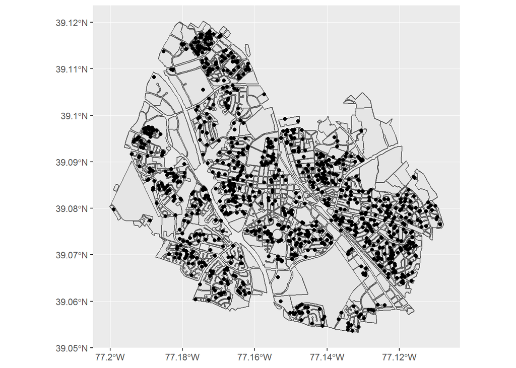

```r
# test to see that these parcels are actually in rockville =
test <- rjoin2 %>%
  filter(rockflag ==1) %>%
  sample_n(1000)

ggplot() +
  geom_sf(rockzoning_sf1, mapping = aes()) +
  geom_sf(test, mapping = aes())
```

```r
# see how this compares to result of moco zoning join
rjoin2 %>%
  as.data.frame() %>%
  count(notinmont, rockflag)
```

```
## # A tibble: 4 x 3
##   notinmont rockflag      n
##       <dbl>    <dbl>  <int>
## 1         0        0 244438
## 2         0        1      8
## 3         1        0  18973
## 4         1        1  16246
```

After the join, we convert back to a dataframe, for ease of computations.

```r
jur5 <- st_set_geometry(rjoin2, NULL)
```

There are 4046 observations that we think are not in montgomery codes, rockville, or gaithersburg.

```r
jur5 %>%
  filter(notinmont == 1 &
           rockflag == 0 &
           gaitflag == 0) %>%
  nrow()
```

```
## [1] 4046
```

## Missing zoning variables

Use the montgomery county zoning layer to fill in any remaining missing zoning variables.

### Missing zoning

```r
jur6 <- jur5 %>%
  # archive the original zoning variable
  mutate(arc_zoning = zoning,
         # fill in whatever we can from the montgomery shape file if it's missing
         zoning = ifelse(is.na(zoning),
                             CODE,
                             zoning))
```

See how many were filled in

```r
sum(is.na(jur6$arc_zoning)) - sum(is.na(jur6$zoning))
```

```
## [1] 11824
```

```r
# look at remaining missing zoning
jur6 %>%
  filter(is.na(zoning) & othernotmoco==0) %>%
  count(category_detail)
```

```
## # A tibble: 7 x 2
##   category_detail        n
##   <chr>              <int>
## 1 apartment              3
## 2 condo                217
## 3 mixeduse               2
## 4 other                114
## 5 sf detached           20
## 6 townhouse             14
## 7 vacant residential  1374
```

Test how many have different results from the Black Knight zoning variable.

```r
jur6 %>%
  group_by(is.na(zoning)) %>%
  count(zoning == CODE)
```

```
## # A tibble: 4 x 3
## # Groups:   is.na(zoning) [2]
##   `is.na(zoning)` `zoning == CODE`      n
##   <lgl>           <lgl>             <int>
## 1 FALSE           FALSE             47039
## 2 FALSE           TRUE             197407
## 3 FALSE           NA                33359
## 4 TRUE            NA                 1860
```

```r
jur6 %>%
  mutate(num = NA) %>%
  group_by(category_detail) %>%
  summarize_at(vars(propaddress, lotsize_sf, zoning, num),
               ~ sum(is.na(.))) %>%
  mutate_at(vars(propaddress, lotsize_sf, zoning),
            .funs = funs(percent = scales::percent(. / num))) %>%
  knitr::kable(caption = "Number and percent of missing values")
```

Number and percent of missing values

| category_detail | propaddress | lotsize_sf | zoning | num | propaddress_percent | lotsize_sf_percent | zoning_percent |
| --- | --- | --- | --- | --- | --- | --- | --- |
| apartment | 8 | 47 | 12 | 914 | 0.9% | 5.1% | 1.3% |
| condo | 5 | 988 | 217 | 17633 | 0.0% | 5.6% | 1.2% |
| mf other | 0 | 2 | 0 | 21 | 0.0% | 9.5% | 0.0% |
| mixeduse | 0 | 1 | 2 | 50 | 0.0% | 2.0% | 4.0% |
| NULL | 0 | 0 | 0 | 2 | 0.0% | 0.0% | 0.0% |
| other | 2040 | 1204 | 138 | 12938 | 15.8% | 9.3% | 1.1% |
| sf detached | 22 | 376 | 65 | 180039 | 0.0% | 0.2% | 0.0% |
| townhouse | 0 | 5 | 14 | 56316 | 0.0% | 0.0% | 0.0% |
| vacant mf | 1 | 18 | 0 | 20 | 5.0% | 90.0% | 0.0% |
| vacant mixed use | 0 | 1 | 0 | 2 | 0.0% | 50.0% | 0.0% |
| vacant residential | 5246 | 2259 | 1412 | 11730 | 44.7% | 19.3% | 12.0% |

```r
count(jur6, is.na(lotsize_sf), category_detail)
```

```
## # A tibble: 21 x 3
##    `is.na(lotsize_sf)` category_detail       n
##    <lgl>               <chr>             <int>
##  1 FALSE               apartment           867
##  2 FALSE               condo             16645
##  3 FALSE               mf other             19
##  4 FALSE               mixeduse             49
##  5 FALSE               NULL                  2
##  6 FALSE               other             11734
##  7 FALSE               sf detached      179663
##  8 FALSE               townhouse         56311
##  9 FALSE               vacant mf             2
## 10 FALSE               vacant mixed use      1
## # ... with 11 more rows
```

## Save and write out

```r
jur6 %>%  as.data.frame() %>%
  count(notinmont, rockflag, gaitflag, othernotmoco)
```

```
## # A tibble: 8 x 5
##   notinmont rockflag gaitflag othernotmoco      n
##       <dbl>    <dbl>    <dbl>        <dbl>  <int>
## 1         0        0        0            0 244425
## 2         0        0        0            1      9
## 3         0        0        1            0      4
## 4         0        1        0            0      8
## 5         1        0        0            0   1713
## 6         1        0        0            1   2333
## 7         1        0        1            0  14927
## 8         1        1        0            0  16246
```

```r
jur6 %>%
  count(category)
```

```
## # A tibble: 4 x 2
##   category      n
##   <chr>     <int>
## 1 mf         6846
## 2 other     12574
## 3 sf       251085
## 4 vacant     9160
```

```r
jur6 <- jur6 %>%
  select(-c(n.overlaps, origins, validgeo, validgeo.x, validgeo.y,
         ALAND, AWATER, FUNCSTAT, NAMELSAD, GEOID,
         BEGINDATE, BEGINREASO, BEGINPLANN, ENDDATE, ENDREASON,
         ENDPLANNER))

saveRDS(jur6,
        paste0(jdir,
               "postcleaned-",
               filepath,
               "-data.Rdata"))
```

### Write out clean data.

```r
write_csv(jur6,
          paste0(jdir,
               "postcleaned-", filepath, "-data.csv"))
```